# Red & White Wine Analysis

# by Sergio Marfull

## About datasets

### Description

This datasets are public available for research. The details are described in [Cortez et al., 2009].

P. Cortez, A. Cerdeira, F. Almeida, T. Matos and J. Reis. *“Modeling wine preferences by data mining from physicochemical properties”*. In Decision Support Systems, Elsevier, 47(4):547-553. ISSN: 0167-9236.

Available at:

- [Elsevier](http://dx.doi.org/10.1016/j.dss.2009.05.016)
- [Pre-press (pdf)](http://www3.dsi.uminho.pt/pcortez/winequality09.pdf)
- bib

### Sample size:

- **Red wine**: 1,599 samples;
- **White wine**: 4,898 samples.

### Attributes:

These datasets consist of 11 attributes and one output variable (below)

- **Fixed acidity** (tartaric acid - $g / dm^3$): most acids involved with wine or fixed or nonvolatile (do not evaporate readily)
- **Volatile acidity** (acetic acid - $g / dm^3$): the amount of acetic acid in wine, which at too high of levels can lead to an unpleasant, vinegar taste
- **Citric acid** ($g / dm^3$): found in small quantities, citric acid can add ‘freshness’ and flavor to wines
- **Residual sugar** ($g / dm^3$): the amount of sugar remaining after fermentation stops, it’s rare to find wines with less than 1 $g/l$ and wines with greater than 45 $g/l$ are considered sweet
- **Chlorides** (sodium chloride - $g / dm^3$): the amount of salt in the wine
- **Free sulfur dioxide** ($mg / dm^3$): the free form of $SO_{2}$ exists in equilibrium between molecular $SO_{2}$ (as a dissolved gas) and bisulfite ion; it prevents microbial growth and the oxidation of wine
- **Total sulfur dioxide** ($mg / dm^3$): amount of free and bound forms of $SO_{2}$; in low concentrations, $SO_{2}$ is mostly undetectable in wine, but at free $SO_{2}$ concentrations over 50 ppm, $SO_{2}$ becomes evident in the nose and taste of wine
- **Density** ($g / cm^3$): the density of water is close to that of water depending on the percent alcohol and sugar content
- **pH**: describes how acidic or basic a wine is on a scale from 0 (very acidic) to 14 (very basic); most wines are between 3-4 on the pH scale
- **Sulphates** (potassium sulphate - $g / dm3$): a wine additive which can contribute to sulfur dioxide gas ($SO_{2}$) levels, wich acts as an antimicrobial and antioxidant
- **Alcohol** (% volume): the percent alcohol content of the wine
- **Quality** (score between 0 and 10): output variable, based on sensory data

### Data Summary:

It will be interesting to combine white and red wine datasets as this could make richer the study. The process of merging them is quite direct as they present identical structure. In order to further analyses, we will add a categorical variable called ‘type’ with ‘red’ and ‘white’ values.

The main scope of this study will be to analyze the main variables that affect the quality of the wine, for both red and white, and if they are the same. In order to simplify that task, we will add another variable called ‘category’ that groups the existing ‘quality’ (1-10) into 3 new categories (‘excellent’, ‘average’,‘deficient’).

For the last sections of the study, we will also use a categorical variable for the alcohol degree with 4 categories (‘<9.5’, ‘9.5-10.5’, ‘10.5-11.5’, ‘>11.5’)

We will also have a look on some similarities and differences between the types of wine throughout the analysis.

```
##  fixed.acidity    volatile.acidity  citric.acid     residual.sugar
##  Min.   : 3.800   Min.   :0.0800   Min.   :0.0000   Min.   : 0.600
##  1st Qu.: 6.400   1st Qu.:0.2300   1st Qu.:0.2500   1st Qu.: 1.800
##  Median : 7.000   Median :0.2900   Median :0.3100   Median : 3.000
##  Mean   : 7.215   Mean   :0.3397   Mean   :0.3186   Mean   : 5.443
##  3rd Qu.: 7.700   3rd Qu.:0.4000   3rd Qu.:0.3900   3rd Qu.: 8.100
##  Max.   :15.900   Max.   :1.5800   Max.   :1.6600   Max.   :65.800
##    chlorides       free.sulfur.dioxide total.sulfur.dioxide
##  Min.   :0.00900   Min.   :  1.00      Min.   :  6.0
##  1st Qu.:0.03800   1st Qu.: 17.00      1st Qu.: 77.0
##  Median :0.04700   Median : 29.00      Median :118.0
##  Mean   :0.05603   Mean   : 30.53      Mean   :115.7
##  3rd Qu.:0.06500   3rd Qu.: 41.00      3rd Qu.:156.0
##  Max.   :0.61100   Max.   :289.00      Max.   :440.0
##     density             pH          sulphates         alcohol
##  Min.   :0.9871   Min.   :2.720   Min.   :0.2200   Min.   : 8.00
##  1st Qu.:0.9923   1st Qu.:3.110   1st Qu.:0.4300   1st Qu.: 9.50
##  Median :0.9949   Median :3.210   Median :0.5100   Median :10.30
##  Mean   :0.9947   Mean   :3.219   Mean   :0.5313   Mean   :10.49
##  3rd Qu.:0.9970   3rd Qu.:3.320   3rd Qu.:0.6000   3rd Qu.:11.30
##  Max.   :1.0390   Max.   :4.010   Max.   :2.0000   Max.   :14.90
##     quality          type                category
##  Min.   :3.000   Length:6497        Deficient: 246
##  1st Qu.:5.000   Class :character   Average  :4974
##  Median :6.000   Mode  :character   Excellent:1277
##  Mean   :5.818
##  3rd Qu.:6.000
##  Max.   :9.000
##              alcoholcat
##  Alcohol < 9.5    :1505
##  Alcohol 9.5-10.5 :1986
##  Alcohol 10.5-11.5:1597
##  Alcohol > 11,5   :1409
##
##
```

We can appreciate that some variables have much variability (residual sugar, free and total sulfur dioxide, chlorides, acidity) due to outliers that can be caused by bad measures for examples. We can also see some 0-values in the variable citric acid, which could be some kind of measuring error or lack of info of these datasets.

## Univariate Plots Section

In this section, we will have a look on the distribution of the different variables for both red and white wines and comparing their distributions to get a deeper understanding of the variables of interest and the key differences between both types of wine.

- **Quality histogram**:

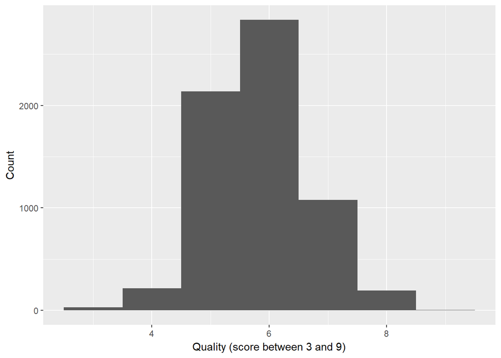

```r
ggplot(wine_data, aes(quality)) +
  geom_histogram(binwidth = 1)+
    labs(x = 'Quality (score between 3 and 9)',
         y = 'Count')
```

We can appreciaty that quality values are normally distributed for the wines.

- **Quality levels histogram**:

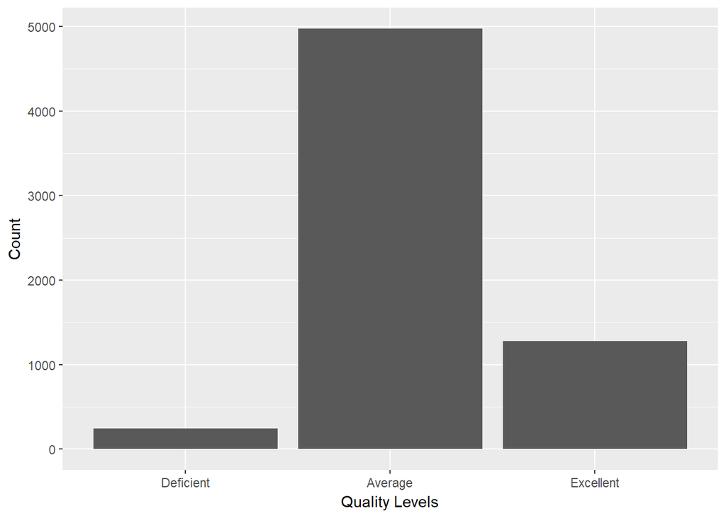

```r
ggplot(wine_data, aes(category)) +
  geom_bar()+
    labs(x = 'Quality Levels',
         y = 'Count')
```

As appreciated before, the quality (now grouped) is normally distributed.

- **Citric acid**:

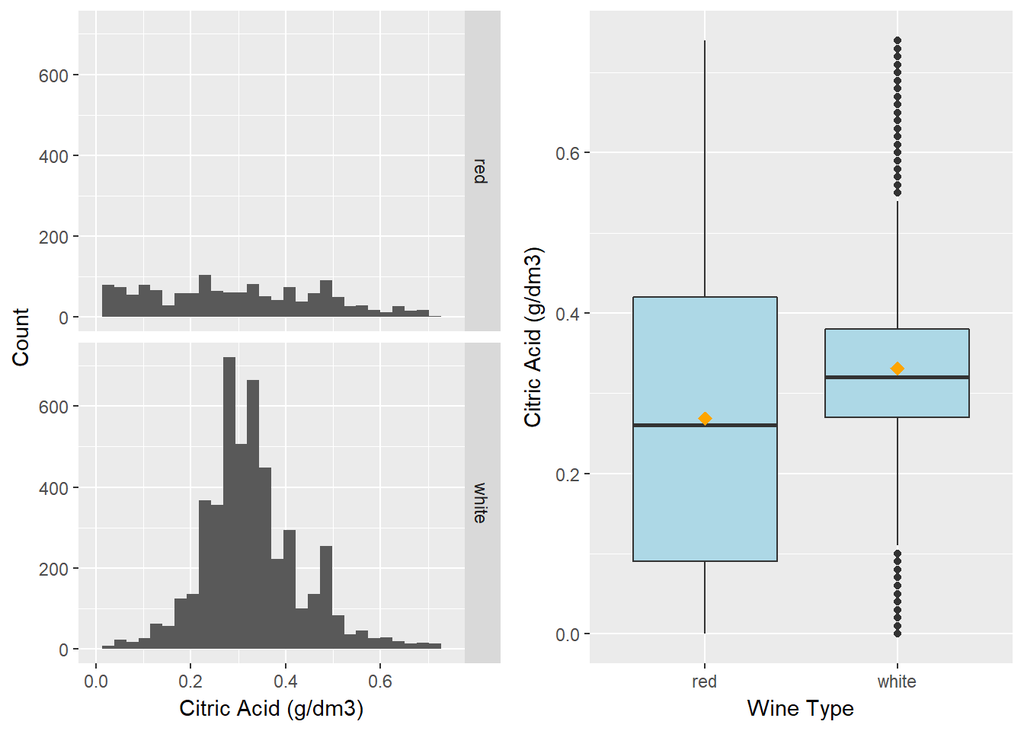

We can see a wide variability of citric acid for the red wine with a quite homogeneous distribution, while white wine is normally distributed. In the boxplot, we can appreciate that variability for the red wine, but both types don’t have significantly different volumes of citric acid

- **Residual sugar**:

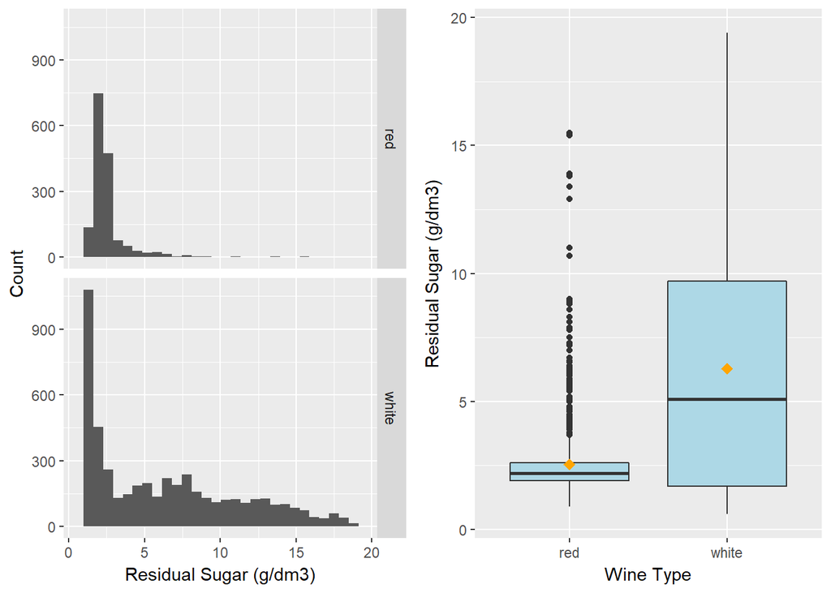

In that case, we appreciate two right-skewed distribution and a clearly wider range of residual sugar volumes for the white wine (2-10) vs. red wine (~2). That makes sense because white wine tastes generally sweeter even though we can also see white wines with similar sugar volumes than white wine.

- **Chlorides**:

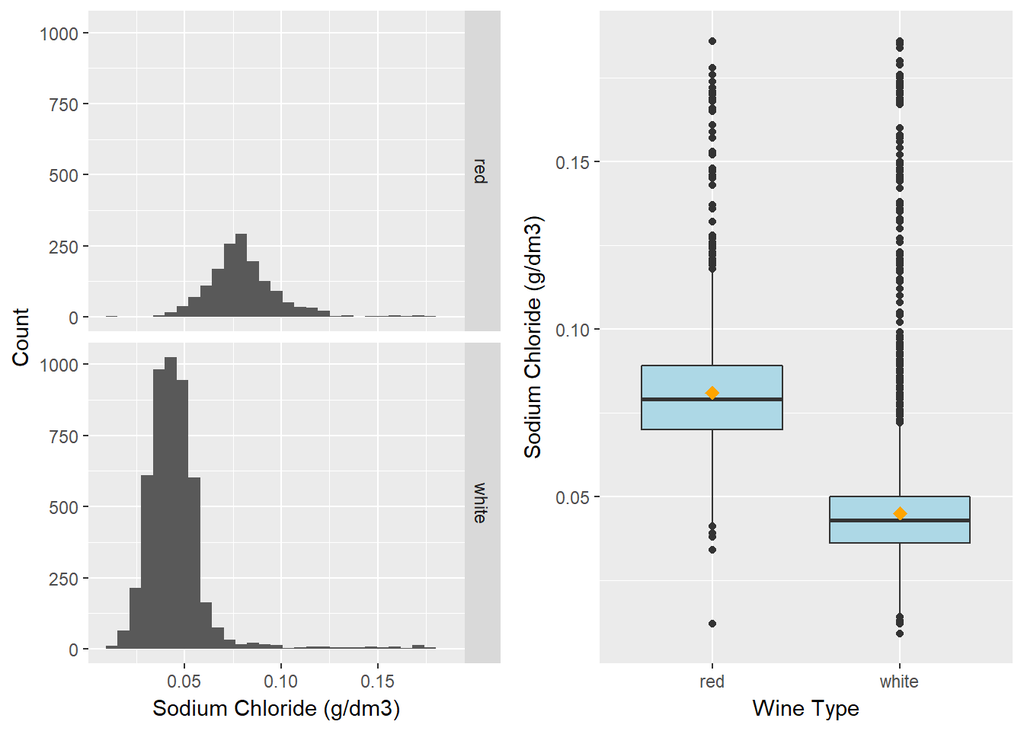

Chlorides are normally distributed for red wine and right-skewed for white wine, with a very long tail. We appreciate that white wine has significantly less volume of chlorides than red wine.

- **Free sulfur dioxide**:

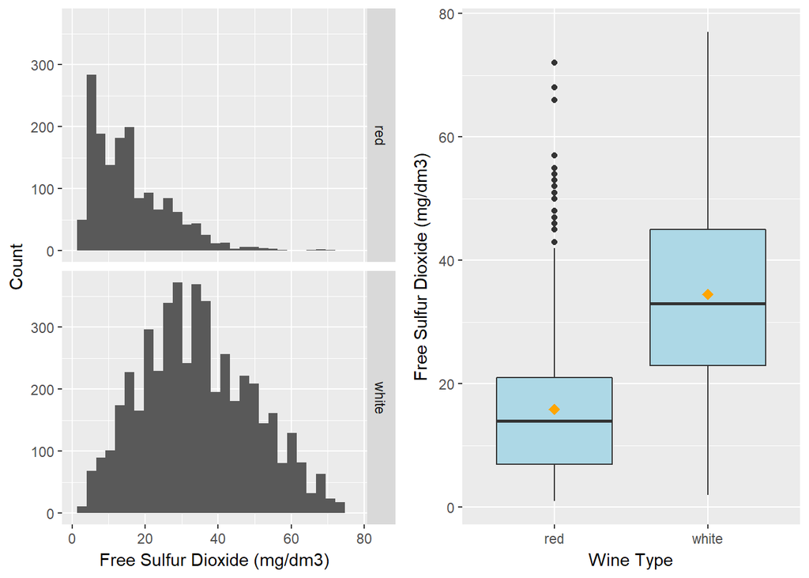

Free sulfure dioxide’s distribution is right-skewed for red wine and normal for white wine. We can appreciate that white wine has significantly more concentration of free sulfure dioxide than red wine.

- **Total sulfur dioxide**:

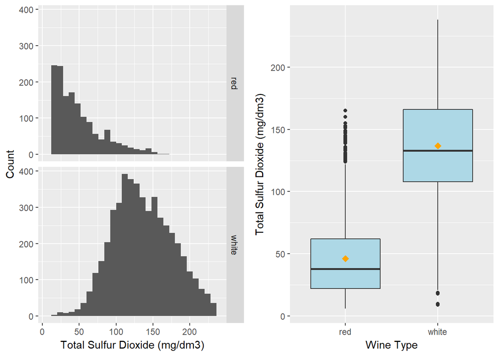

We appreciate a right-skewed distribution for red wine and a slightly left-skewed distribution for white wine. In that case, we can see that total sulfure dioxide volumes are significantly higher for white wine.

- **Density**:

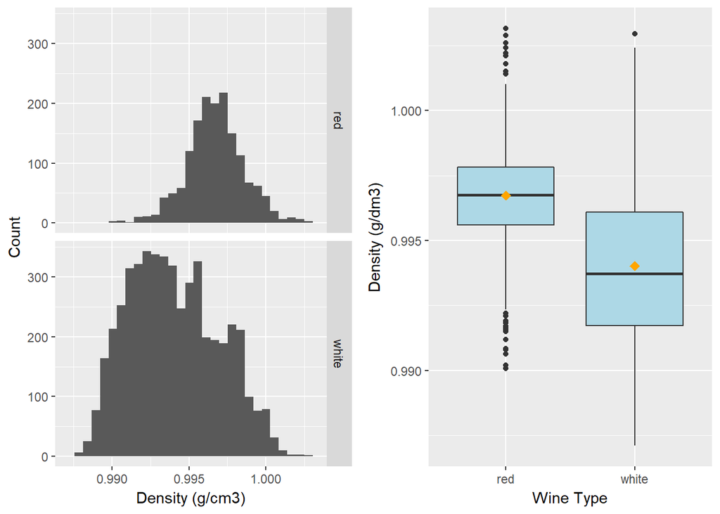

Both wines seem to be normally distributed and red wines seem to have slightly higher density than white even though their boxplots overlap.

- **pH**:

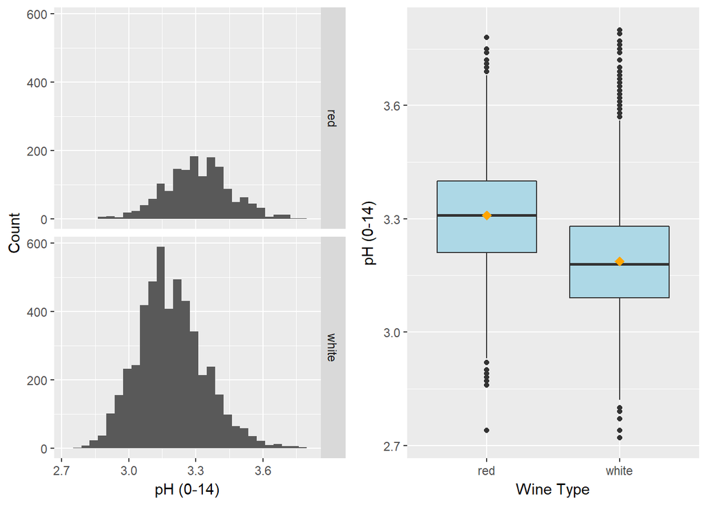

pH is normally distributed for both wines and seems slightly higher for red wine.

- **Sulphates**:

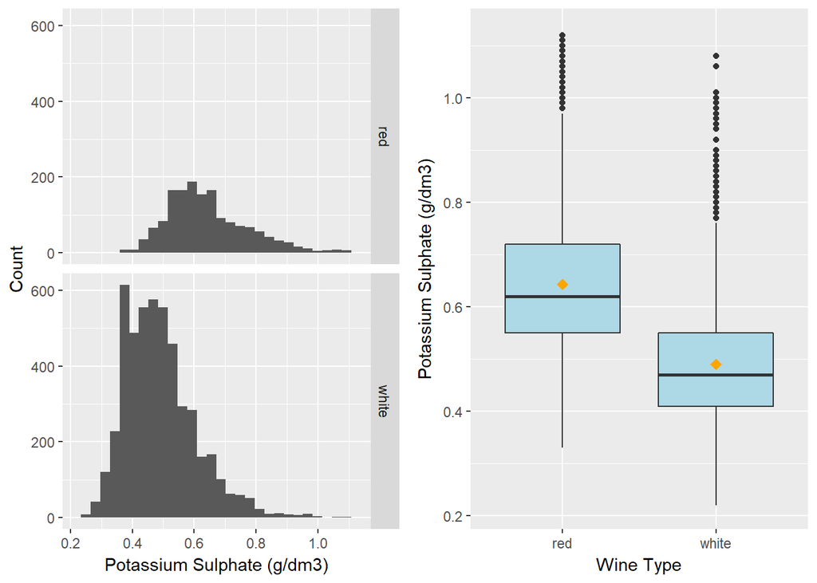

Sulphates have a right-skewed distribution for both wines. Its concentration seems to be slightly higher for red wine.

- **Alcohol**:

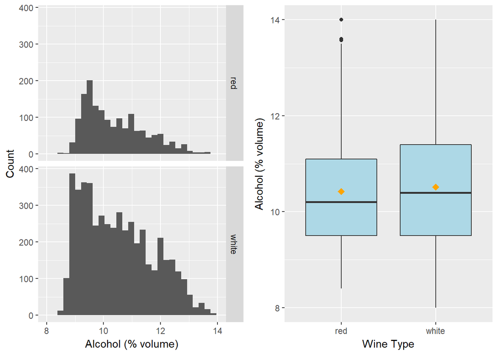

Alcohol volume distribution is right-skewed for both wines. We can’t appreciate that both types of wine have significantly different alcohol degrees as they have very similar boxplots and mean.

## Univariate Analysis

#### What is the structure of your dataset?

We have a sample size of 6497 wines (1599 red and 4898 white).

#### What is/are the main feature(s) of interest in your dataset?

The main feature will be quality and we will try to determine the variables that make wine taste better.

#### What other features in the dataset do you think will help support your

#### investigation into your feature(s) of interest?

Probably, alcohol, residual sugar, pH, acid and density will affect the quality.

#### Did you create any new variables from existing variables in the dataset?

Yes, I added one column for the type of wine (red or white) and another one for the quality divided in three groups (excellent, average and deficient)

#### Of the features you investigated, were there any unusual distributions?

#### Did you perform any operations on the data to tidy, adjust, or change the

#### form of the data? If so, why did you do this?

There where outliers in most of the features. I trimmed some outliers little quantiles (<0.1) when plotting their distributions in order to appreciate them clearer.

## Bivariate Plots Section

- **Red&White feature correlation together:**

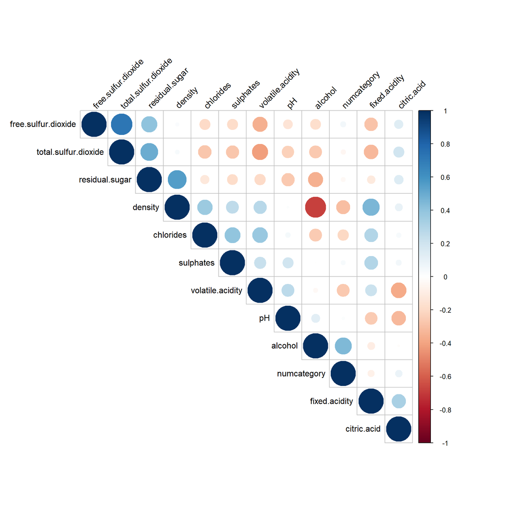

```
##                      fixed.acidity volatile.acidity citric.acid
## fixed.acidity           1.00000000       0.21900826  0.32443573
## volatile.acidity        0.21900826       1.00000000 -0.37798132
## citric.acid             0.32443573      -0.37798132  1.00000000
## residual.sugar         -0.11198128      -0.19601117  0.14245123
## chlorides               0.29819477       0.37712428  0.03899801
## free.sulfur.dioxide    -0.28273543      -0.35255731  0.13312581
## total.sulfur.dioxide   -0.32905390      -0.41447619  0.19524198
## density                 0.45890998       0.27129565  0.09615393
## pH                     -0.25270047       0.26145440 -0.32980819
## sulphates               0.29956774       0.22598368  0.05619730
## alcohol                -0.09545152      -0.03764039 -0.01049349
## numcategory            -0.07674321      -0.26569948  0.08553172
##                      residual.sugar   chlorides free.sulfur.dioxide
## fixed.acidity           -0.11198128  0.29819477         -0.28273543
## volatile.acidity        -0.19601117  0.37712428         -0.35255731
## citric.acid              0.14245123  0.03899801          0.13312581
## residual.sugar           1.00000000 -0.12894050          0.40287064
## chlorides               -0.12894050  1.00000000         -0.19504479
## free.sulfur.dioxide      0.40287064 -0.19504479          1.00000000
## total.sulfur.dioxide     0.49548159 -0.27963045          0.72093408
## density                  0.55251695  0.36261466          0.02571684
## pH                      -0.26731984  0.04470798         -0.14585390
## sulphates               -0.18592741  0.39559331         -0.18845725
## alcohol                 -0.35941477 -0.25691558         -0.17983843
## numcategory             -0.03698048 -0.20066550          0.05546306
##                      total.sulfur.dioxide     density          pH
## fixed.acidity                 -0.32905390  0.45890998 -0.25270047
## volatile.acidity              -0.41447619  0.27129565  0.26145440
## citric.acid                    0.19524198  0.09615393 -0.32980819
## residual.sugar                 0.49548159  0.55251695 -0.26731984
## chlorides                     -0.27963045  0.36261466  0.04470798
## free.sulfur.dioxide            0.72093408  0.02571684 -0.14585390
## total.sulfur.dioxide           1.00000000  0.03239451 -0.23841310
## density                        0.03239451  1.00000000  0.01168608
## pH                            -0.23841310  0.01168608  1.00000000
## sulphates                     -0.27572682  0.25947850  0.19212341
## alcohol                       -0.26573964 -0.68674542  0.12124847
## numcategory                   -0.04138545 -0.30585791  0.01950570
##                         sulphates      alcohol numcategory
## fixed.acidity         0.299567744 -0.095451523 -0.07674321
## volatile.acidity      0.225983680 -0.037640386 -0.26569948
## citric.acid           0.056197300 -0.010493492  0.08553172
## residual.sugar       -0.185927405 -0.359414771 -0.03698048
## chlorides             0.395593307 -0.256915580 -0.20066550
## free.sulfur.dioxide  -0.188457249 -0.179838435  0.05546306
## total.sulfur.dioxide -0.275726820 -0.265739639 -0.04138545
## density               0.259478495 -0.686745422 -0.30585791
## pH                    0.192123407  0.121248467  0.01950570
## sulphates             1.000000000 -0.003029195  0.03848545
## alcohol              -0.003029195  1.000000000  0.44431852
## numcategory           0.038485446  0.444318520  1.00000000
```

For the merged dataset, we can easily appreciate on the plot the strong inverse correlation between alcohol and density (-0.69), what makes sense because a higher alcohol degree is lowering the density of the wine. We also see other pairs of variables strongly correlated like total.sulfur.dioxide and free.sulfure.dioxide (0.72) and some others with correlation >=0.5: total sulfur dioxide and residual sugar, density and residual sugar.

- **Red Wine feature correlation:**

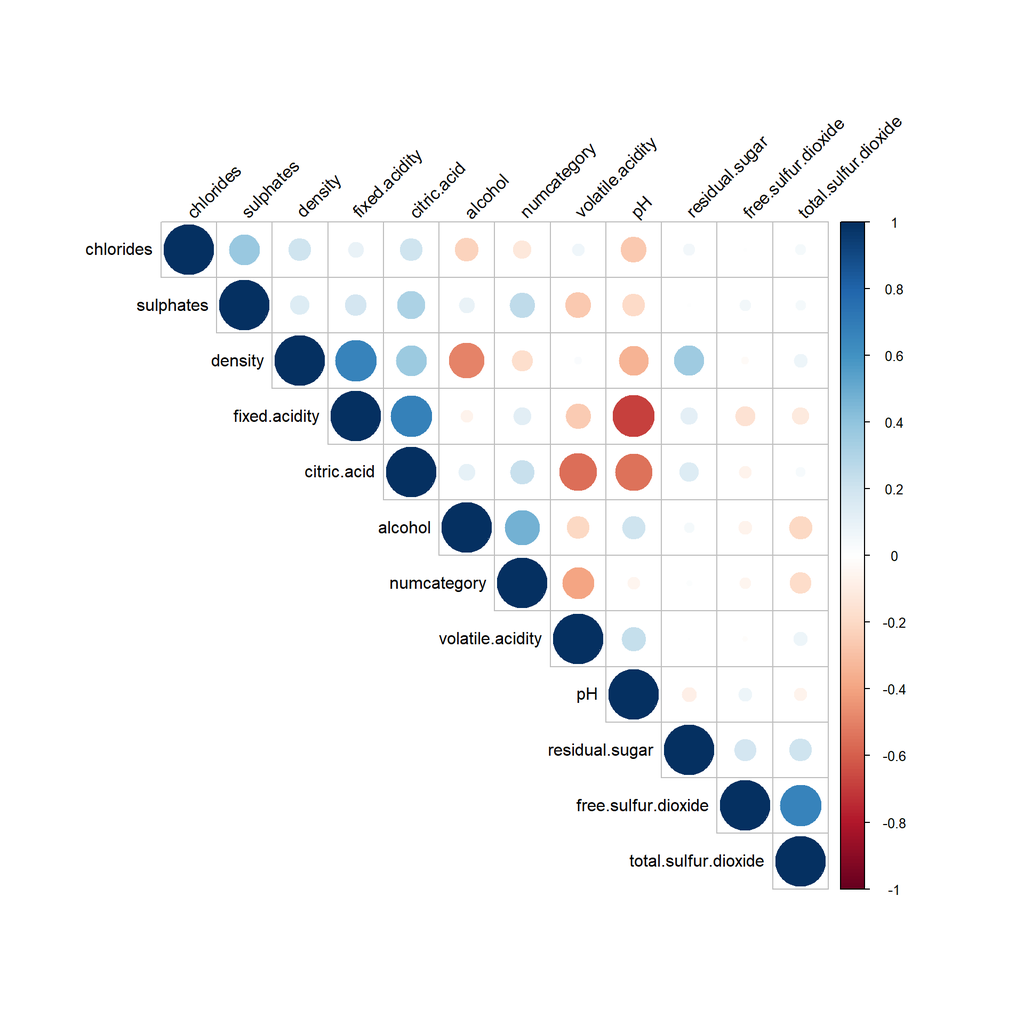

```
##                      fixed.acidity volatile.acidity citric.acid
## fixed.acidity           1.00000000     -0.256130895  0.67170343
## volatile.acidity       -0.25613089      1.000000000 -0.55249568
## citric.acid             0.67170343     -0.552495685  1.00000000
## residual.sugar          0.11477672      0.001917882  0.14357716
## chlorides               0.09370519      0.061297772  0.20382291
## free.sulfur.dioxide    -0.15379419     -0.010503827 -0.06097813
## total.sulfur.dioxide   -0.11318144      0.076470005  0.03553302
## density                 0.66804729      0.022026232  0.36494718
## pH                     -0.68297819      0.234937294 -0.54190414
## sulphates               0.18300566     -0.260986685  0.31277004
## alcohol                -0.06166827     -0.202288027  0.10990325
## numcategory             0.12405165     -0.390557780  0.22637251
##                      residual.sugar    chlorides free.sulfur.dioxide
## fixed.acidity           0.114776724  0.093705186        -0.153794193
## volatile.acidity        0.001917882  0.061297772        -0.010503827
## citric.acid             0.143577162  0.203822914        -0.060978129
## residual.sugar          1.000000000  0.055609535         0.187048995
## chlorides               0.055609535  1.000000000         0.005562147
## free.sulfur.dioxide     0.187048995  0.005562147         1.000000000
## total.sulfur.dioxide    0.203027882  0.047400468         0.667666450
## density                 0.355283371  0.200632327        -0.021945831
## pH                     -0.085652422 -0.265026131         0.070377499
## sulphates               0.005527121  0.371260481         0.051657572
## alcohol                 0.042075437 -0.221140545        -0.069408354
## numcategory             0.013731637 -0.128906560        -0.050656057
##                      total.sulfur.dioxide     density          pH
## fixed.acidity                 -0.11318144  0.66804729 -0.68297819
## volatile.acidity               0.07647000  0.02202623  0.23493729
## citric.acid                    0.03553302  0.36494718 -0.54190414
## residual.sugar                 0.20302788  0.35528337 -0.08565242
## chlorides                      0.04740047  0.20063233 -0.26502613
## free.sulfur.dioxide            0.66766645 -0.02194583  0.07037750
## total.sulfur.dioxide           1.00000000  0.07126948 -0.06649456
## density                        0.07126948  1.00000000 -0.34169933
## pH                            -0.06649456 -0.34169933  1.00000000
## sulphates                      0.04294684  0.14850641 -0.19664760
## alcohol                       -0.20565394 -0.49617977  0.20563251
## numcategory                   -0.18510029 -0.17491923 -0.05773139
##                         sulphates     alcohol numcategory
## fixed.acidity         0.183005664 -0.06166827  0.12405165
## volatile.acidity     -0.260986685 -0.20228803 -0.39055778
## citric.acid           0.312770044  0.10990325  0.22637251
## residual.sugar        0.005527121  0.04207544  0.01373164
## chlorides             0.371260481 -0.22114054 -0.12890656
## free.sulfur.dioxide   0.051657572 -0.06940835 -0.05065606
## total.sulfur.dioxide  0.042946836 -0.20565394 -0.18510029
## density               0.148506412 -0.49617977 -0.17491923
## pH                   -0.196647602  0.20563251 -0.05773139
## sulphates             1.000000000  0.09359475  0.25139708
## alcohol               0.093594750  1.00000000  0.47616632
## numcategory           0.251397079  0.47616632  1.00000000
```

For the red wine data, we can see strong inverse correlation between alcohol fixed acidity and pH (-0.68), citric acid and pH (-0.54), and citric acid and volatile acidity (-0.55). We also find direct correlation between fixed acidity and citric acid (0.67), density and fixed acidity (0.67), and total sulfur dioxide and free sulfur dioxide (0.67).

Regarding the variable of interest, it gets its higher correlation with alcohol (0.48) for this wine.

- **White Wine feature correlation:**

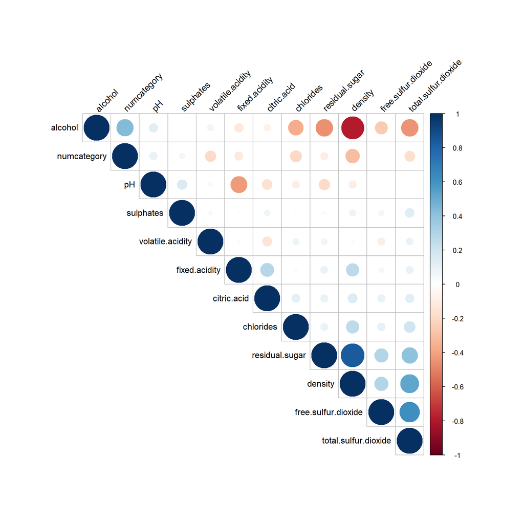

```
##                      fixed.acidity volatile.acidity  citric.acid
## fixed.acidity           1.00000000      -0.02269729  0.289180698
## volatile.acidity       -0.02269729       1.00000000 -0.149471811
## citric.acid             0.28918070      -0.14947181  1.000000000
## residual.sugar          0.08902070       0.06428606  0.094211624
## chlorides               0.02308564       0.07051157  0.114364448
## free.sulfur.dioxide    -0.04939586      -0.09701194  0.094077221
## total.sulfur.dioxide    0.09106976       0.08926050  0.121130798
## density                 0.26533101       0.02711385  0.149502571
## pH                     -0.42585829      -0.03191537 -0.163748211
## sulphates              -0.01714299      -0.03572815  0.062330940
## alcohol                -0.12088112       0.06771794 -0.075728730
## numcategory            -0.11366283      -0.19472297 -0.009209091
##                      residual.sugar   chlorides free.sulfur.dioxide
## fixed.acidity            0.08902070  0.02308564       -0.0493958591
## volatile.acidity         0.06428606  0.07051157       -0.0970119393
## citric.acid              0.09421162  0.11436445        0.0940772210
## residual.sugar           1.00000000  0.08868454        0.2990983537
## chlorides                0.08868454  1.00000000        0.1013923521
## free.sulfur.dioxide      0.29909835  0.10139235        1.0000000000
## total.sulfur.dioxide     0.40143931  0.19891030        0.6155009650
## density                  0.83896645  0.25721132        0.2942104109
## pH                      -0.19413345 -0.09043946       -0.0006177961
## sulphates               -0.02666437  0.01676288        0.0592172458
## alcohol                 -0.45063122 -0.36018871       -0.2501039415
## numcategory             -0.09757683 -0.20993441        0.0081580671
##                      total.sulfur.dioxide     density            pH
## fixed.acidity                 0.091069756  0.26533101 -0.4258582910
## volatile.acidity              0.089260504  0.02711385 -0.0319153683
## citric.acid                   0.121130798  0.14950257 -0.1637482114
## residual.sugar                0.401439311  0.83896645 -0.1941334540
## chlorides                     0.198910300  0.25721132 -0.0904394560
## free.sulfur.dioxide           0.615500965  0.29421041 -0.0006177961
## total.sulfur.dioxide          1.000000000  0.52988132  0.0023209718
## density                       0.529881324  1.00000000 -0.0935914935
## pH                            0.002320972 -0.09359149  1.0000000000
## sulphates                     0.134562367  0.07449315  0.1559514973
## alcohol                      -0.448892102 -0.78013762  0.1214320987
## numcategory                  -0.174737218 -0.30712331  0.0994272457
##                        sulphates     alcohol  numcategory
## fixed.acidity        -0.01714299 -0.12088112 -0.113662831
## volatile.acidity     -0.03572815  0.06771794 -0.194722969
## citric.acid           0.06233094 -0.07572873 -0.009209091
## residual.sugar       -0.02666437 -0.45063122 -0.097576829
## chlorides             0.01676288 -0.36018871 -0.209934411
## free.sulfur.dioxide   0.05921725 -0.25010394  0.008158067
## total.sulfur.dioxide  0.13456237 -0.44889210 -0.174737218
## density               0.07449315 -0.78013762 -0.307123313
## pH                    0.15595150  0.12143210  0.099427246
## sulphates             1.00000000 -0.01743277  0.053677877
## alcohol              -0.01743277  1.00000000  0.435574715
## numcategory           0.05367788  0.43557472  1.000000000
```

- **Density vs. Alcohol:**

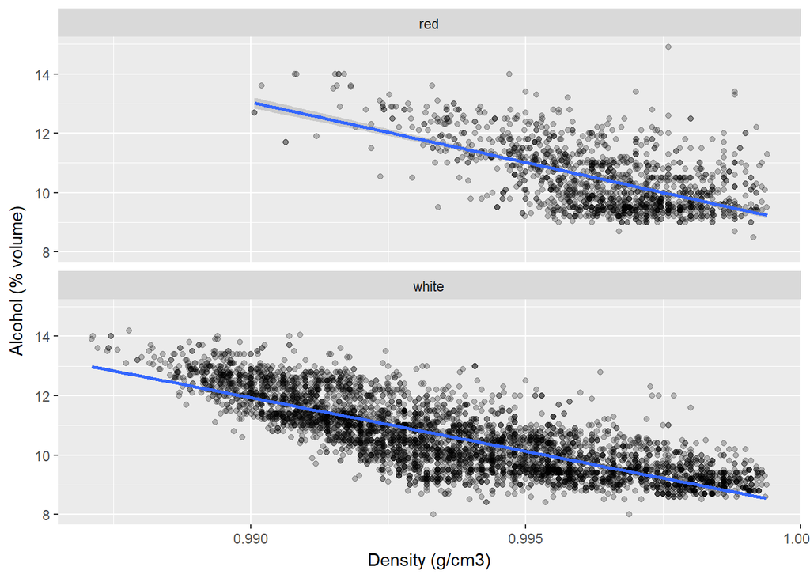

- **Density vs. Residual sugar:**

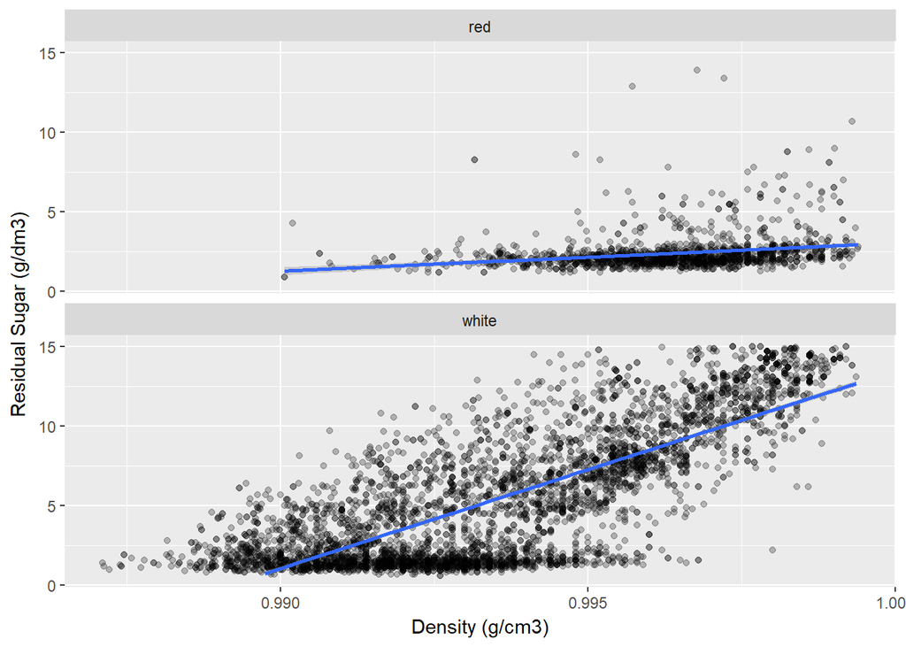

We can also see a strong correlation between residual sugar and density in the white wine (0.84), while red wine has a notably lower correlation (0.36). This makes sense as white wine use to be sweeter and that quantity of residual sugar makes the difference for the density.

- **Total sulfur dioxide vs. Free sulfur dioxide:**

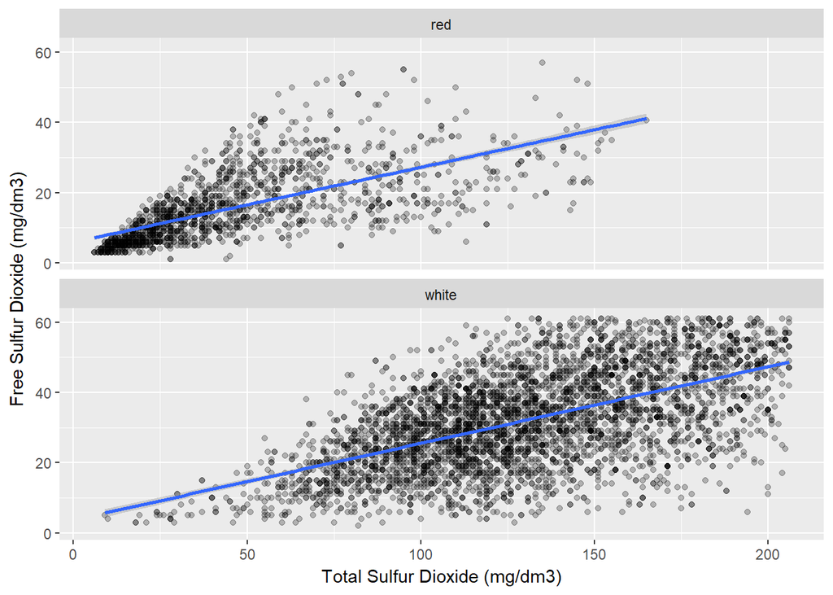

In this case, both have similar correlations: red wine (0.67) and white wine (0.62).

- **Quality vs. Alcohol:**

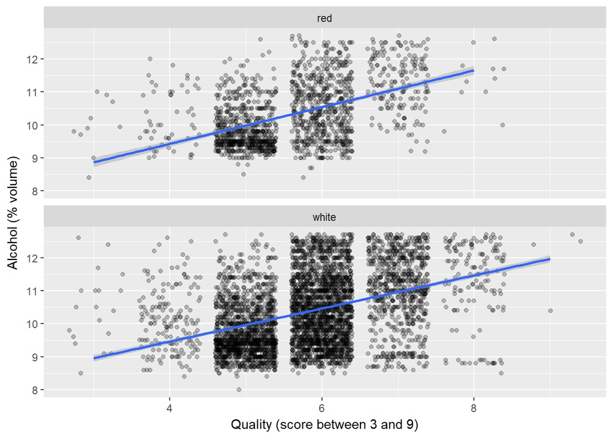

The correlation for both wines exist, even though is not the strongest (0.4-0.5)

Based on what we have just found out on correlations, we will break down the quality in three categories and analyze what features affect the most to good and bad wines.

- **Category vs. Alcohol:**

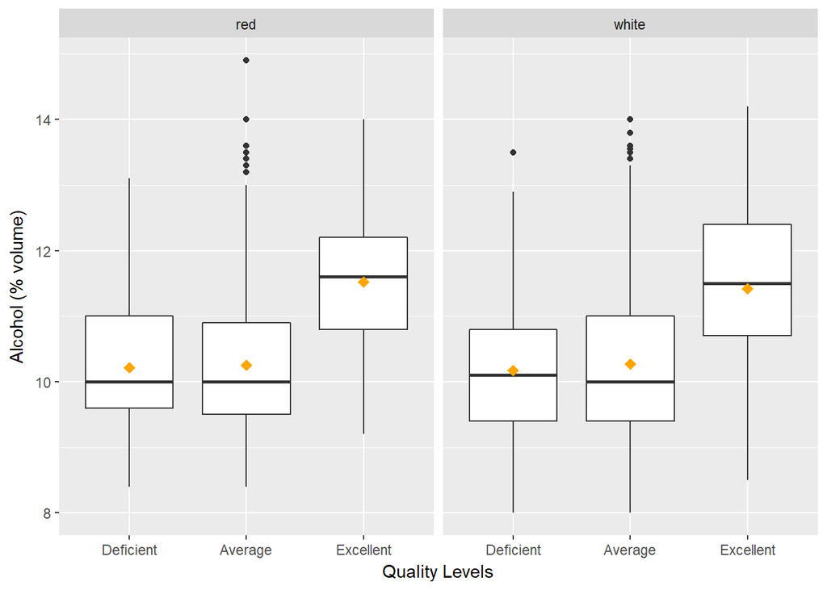

More alcohol, usually means a significative better wine for graduation higher than 11 degrees.

- **Category vs. Density:**

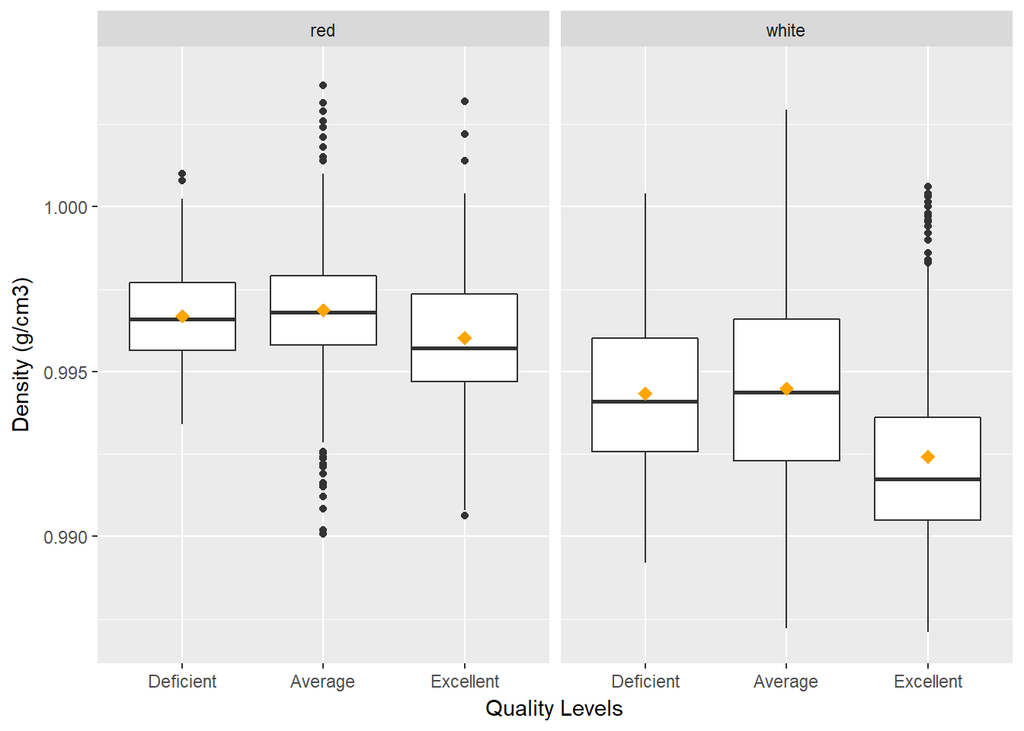

For white wines, the excellent wines seem to have a lower density, what makes sense as density has a strong inverse correlation with the degree of alcohol.

- **Category vs. Volatile Acidity:**

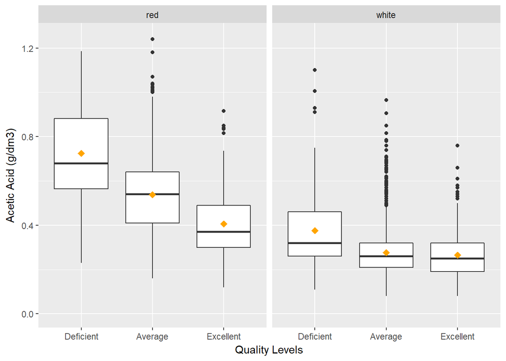

For red wines, higher concentrations of acetic acid (volatile acidity) mean worse wines. The lower concentration, the better seems to be the red wine.

## Bivariate Analysis

#### Talk about some of the relationships you observed in this part of the

#### investigation. How did the feature(s) of interest vary with other features

#### in the dataset?

The feature of interest has an important direct correlation with alcohol. It means that a bigger degree of alcohol means a higher quality of the wine generally.

Breaking down the quality in three categories, we find out that the excellent wines for both red and white types seem to be those with an alcohol degree greater than 11.

#### Did you observe any interesting relationships between the other features

#### (not the main feature(s) of interest)?

Yes, there are some interesting relationships between density and alcohol and density and residual sugar, that makes us think of the rol of sugar in white wine and the lower density of alcohol compared to water, for example.

#### What was the strongest relationship you found?

It was density vs. residual sugar for the white wine: a direct correlation of 0.84.

## Multivariate Plots Section

For the following plots, we defined another categorical variable that splits up the degree of alcohol in 4 categories, as we saw the importance of this feature in the quality of both red and white wine

- **Red wine:Alcohol, Quality, Citric Acid and Acetic Acid**

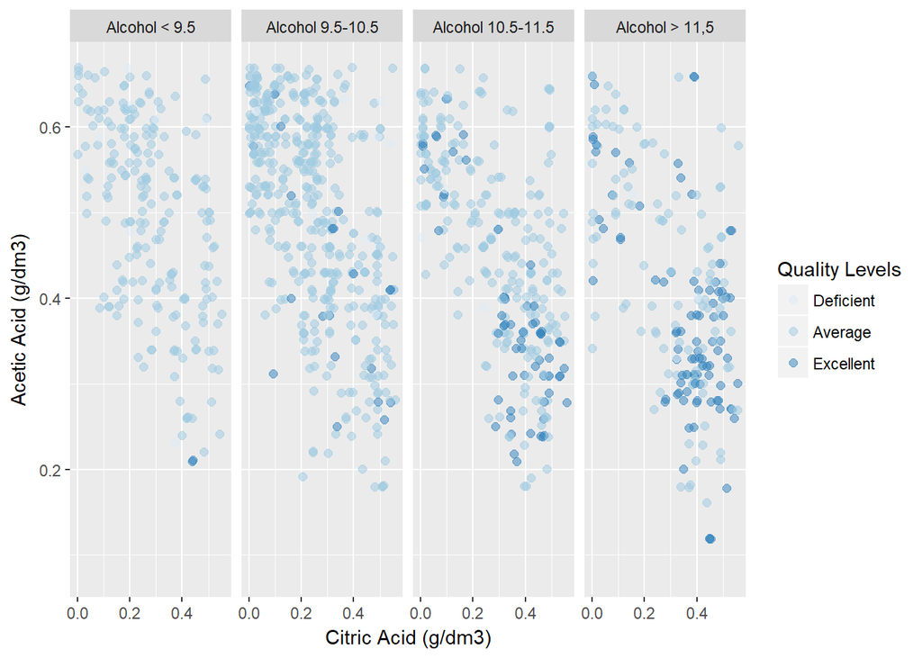

In this plot, we can clearly observe a trend for red wine by which the wines with higher level of alcohol, less concentration of acetic acid and more concentration of citric acid, get the better qualifications.

- **White wine: Alcohol, Quality, Chlorides and Density**

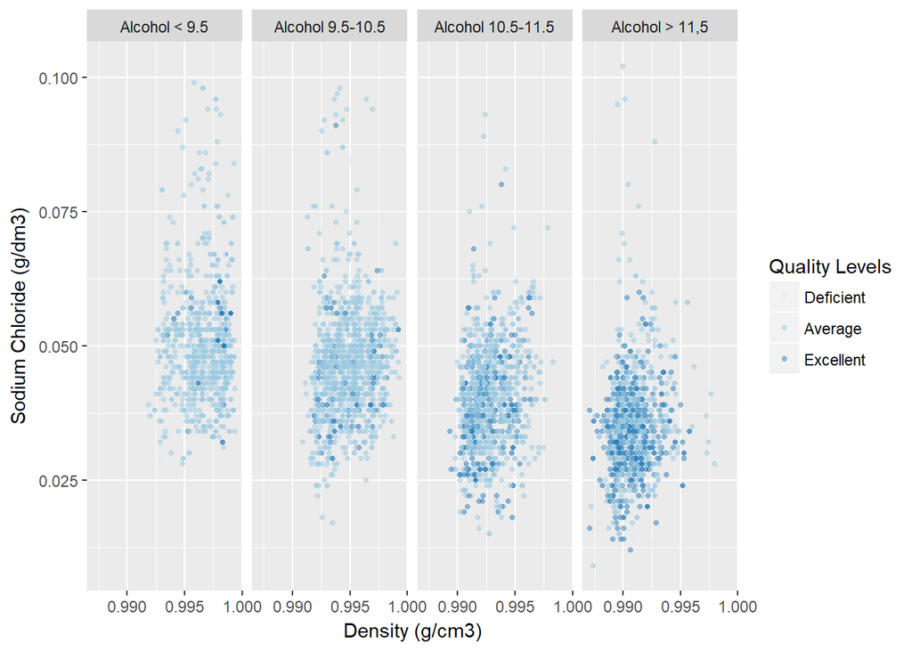

## Multivariate Analysis

#### Talk about some of the relationships you observed in this part of the

#### investigation. Were there features that strengthened each other in terms of

#### looking at your feature(s) of interest?

Doing this allow us to visualize clearly, for red and white wine, that these features shift the scatter plot and make the difference.

#### Were there any interesting or surprising interactions between features?

Yes, citric and acetic acid concentration for red wine and density and chlorides for white wine.

## Final Plots and Summary

#### Plot One: Degree of alcohol. Difference between red and white?

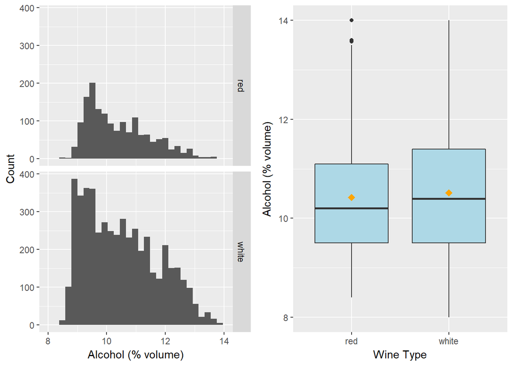

#### Description One

Personally, I had always thought that white wines had significantly more degree of alcohol but in these plots we can clearly see very similar distributions, as well as parameters (mean, median and quantiles). So that, the alcohol doesn’t seem to be a significative feature between both types of wine.

#### Plot Two: Boxplot: wine category and alcohol degree

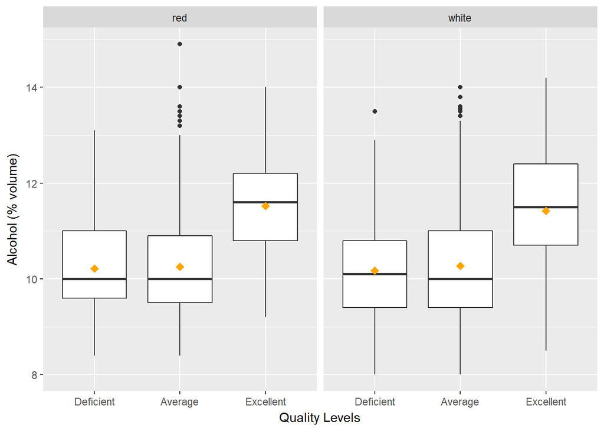

#### Description Two

We observed that the highest correlation between one feature and the quality of the wine was the degree of alcohol for both wines, even though it is not a strong correlation: 0.48 for red wine and 0.43 for white wine.

With this plot two, we break down the samples of both types of wine in deficient, average and excellent wines. And, surprisingly, excellent wines seem to be a higher degree of alcohol (more than 11 degrees). It seemed misleading for me because drinks with higher degree of alcohol usually taste stronger.

#### Plot Three: Alcohol, Quality, Chlorides and Density

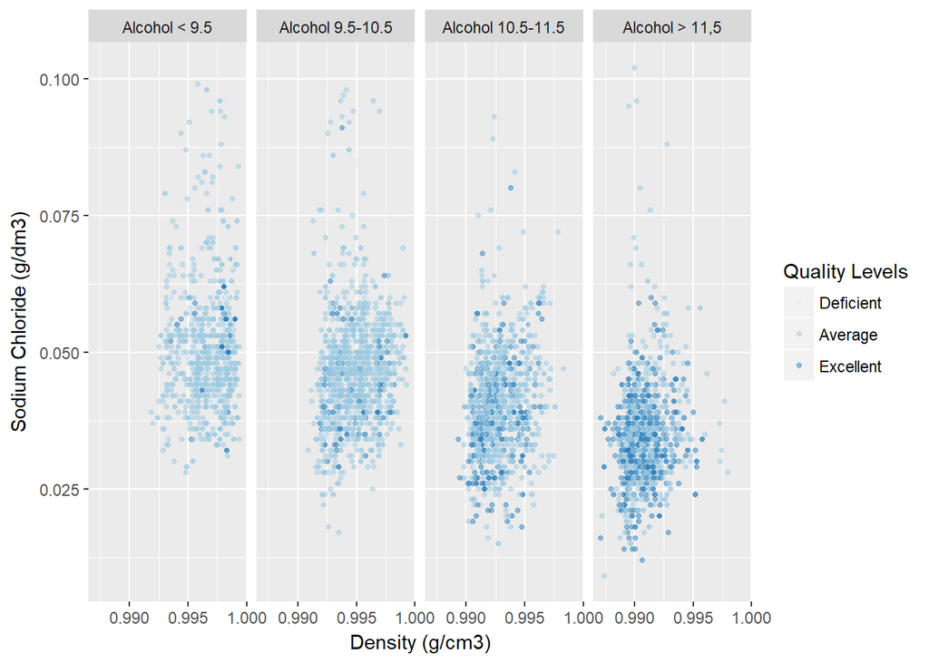

## Reflection

By analyzing this data, we have come to some ideas that can be new for some of us.

1. Red and white wine are different in many aspects (citric acid, residual sugar, chlorides, sulfure dioxide, density, pH,…) but the one they are more similar is the one which has more to do with the taste of excellent wines: the alcohol degree
2. Nevertheless, we observe different features for each kind of wine that affect the flavor: citric acid and acetic acid concentration for red wine and chlorides and density (affected as well for the concentration of residual sugar) for white wine

So according to this analysis, the main feature that affects the flavor of a good wine is the degree of alcohol, which should be higher than 11. Moreover, if you are going to produce your own wine, you should take into account the other features we commented for red and white wine, so you can assure an excellent taste for your production.

I got struggle with merging the data at first and with plotting correctly because of the different scales. I had to visit often “Stackoverflow” in order to get through course limitation and my own.

Next steps of this analysis may include a larger number of samples for the red wine dataset so we have similar number of samples in both datasets that we merged. We can also consider other kind of plots and add a linear model.

If we got a large enough dataset, we could also create a predictive model with Machine Learning algorithms and use it to identify the color of the wine or the expected taste based on the other parameters.

For future exploration of this data I would pick one category of wine (for example, quality level 3-4, 5-7, 8-9) to look at the patterns which can appear in each of these three buckets. I also would normalize data because we have more white wine than red wine.